# EM算法

本文分享了EM算法的两个实践案例，一个是关于两分类的GMM模型，一个是多项分布的混合主题模型。

## 1.Two-component Gaussian mixture model

### 1.1

We can know that

$$f(x|\theta)=\tau N(x|\mu_1,\sigma_1^2)+(1-\tau)N(x|\mu_2,\sigma_2^2)$$

$$\begin{split}
L(X, Z|\theta) &= \prod_{i=1}^n \pi_k^{Z_{i1}} N(x_i|\theta)^{Z_{i1}}\pi_k^{Z_{i2}} N(x_i|\theta)^{Z_{i2}}
\end{split}$$

$$l(\theta|x,z)=\sum_{i=1}^n Z_{i,1} \left( \log (\pi_1) + \log (N(x_i|\mu_1, \sigma_1^2) )\right)+Z_{i,2} \left( \log (\pi_2) + \log (N(x_i|\mu_2, \sigma_2^2) )\right)$$

$$\begin{split}
Q(\theta|\theta^{(t)})&=E[\sum_{i=1}^n[Z_{i,1}logN(x_i|\mu_1,\sigma_1^2)+Z_{i,2}logN(x_i|\mu_2,\sigma_2^2)]]+constant\\&:=\sum_{i=1}^n[E[Z_{i,1}|x,\theta^{(t)}][-\frac{1}{2}log(2\pi \sigma^2_1)-\frac{1}{2\sigma_1^2}(x_i-\mu_1)^2]+E[Z_{i,2}|x,\theta^{(t)}][-\frac{1}{2}log(2\pi \sigma^2_2)-\frac{1}{2\sigma_2^2}(x_i-\mu_2)^2]]
\end{split}$$

### 1.2

Do the M-step

$$Max\space \space Q(\theta|\theta^{(t)})$$

$$[\mu_k]:-0.5\sum_{i=1}^nZ_{i,k}^{(t)}(-2)(x_i-\mu_k)=0$$
So

$$\mu_k^{(t+1)}=\frac{\sum_{i=1}^nZ_{i,k}^{(t)}x_i}{\sum_{i=1}^nZ_{i,k}^{(t)}}$$
$$[\sigma^2_k]:\sum_{i=1}^nZ_{i,k}^{(t)}(-\frac{1}{2 \sigma_k^2}+\frac{(x_i-\mu_k)^2}{2\sigma_k^4})=0$$
$$\sigma_k^2{(t+1)}=\frac{\sum_{i=1}^nZ_{i,k}^{(t)}(x_i-\mu_k)^2}{\sum_{i=1}^nZ_{i,k}^{(t)}}$$
$$Z_{i,k}^{(t+1)}=\frac{\sum_{i=1}^nZ_{i,k}^{(t)}}{n}$$

### 1.3

The function called my_gmm_em is the function of GMM model with E-M algorithm.

```r
my_gmm_em=function(k,samp,iteration){
n=length(samp)
prob <- matrix(rep(0, k*n), nrow = n)
weight <- matrix(rep(0, k*n), nrow = n)
threshold <- 1e-5

tau <- c(0.5, 0.5)
miu   <- runif(k)
sigma <- runif(k)

out_tau=matrix(rep(0,k*iteration),nrow=iteration)
out_miu=matrix(rep(0,k*iteration),nrow=iteration)
out_sigma=matrix(rep(0,k*iteration),nrow=iteration)

out_tau[1,]=tau
out_miu[1,]=miu
out_sigma[1,]=sigma

for (step in 1:iteration) {
  for (j in 1:k) {
    prob[, j]   <- sapply(samp, dnorm, miu[j], sigma[j])
    weight[, j] <- tau[j] * prob[, j]
  }
  row_sum <- rowSums(weight)
  prob    <- weight/row_sum


  oldtau <- tau
  oldmiu   <- miu
  oldsigma <- sigma



  for (j in 1:k) {
    sum1     <- sum(prob[, j])
    sum2     <- sum(samp*prob[, j])
    tau[j] <- sum1/n
    miu[j]   <- sum2/sum1
    sum3     <- sum(prob[, j]*(samp-miu[j])^2)
    sigma[j] <- sqrt(sum3/sum1)
  }

  out_tau[step,]=tau
  out_miu[step,]=miu
  out_sigma[step,]=sigma
  #if (sum(abs(tau - oldtau)) < threshold &
      #sum(abs(miu - oldmiu))     < threshold &
      #sum(abs(sigma - oldsigma)) < threshold) break

}
return(mylist=list("tau"=out_tau,"miu"=out_miu,"sigma"=out_sigma))
}
```

The code below aims to generate the data, and then run the GMM code. The out put is $\theta$

```r
set.seed(100000)
n <- 100

tau1 <- 0.3
miu1   <- 0
sigma1 <- 1


tau2 <- 0.7
miu2   <- 2
sigma2 <- 0.5

n1 <- floor(n*tau1)
n2 <- n-n1

samp <-numeric(n)
samp[1:n1] <- rnorm(n1, miu1, sigma1)
samp[(n1+1):n] <- rnorm(n2, miu2, sigma2)
out=my_gmm_em(2,samp,200)
```

```r
print(paste("Final Estimate of tau = (",out$tau[200,1],",",out$tau[200,2],")"))
```

```
## [1] "Final Estimate of tau = ( 0.323950241780784 , 0.676049758219216 )"
```

```r
print(paste("Final Estimate of miu = (",out$miu[200,1],",",out$miu[200,2],")"))
```

```
## [1] "Final Estimate of miu = ( 0.0606505669653436 , 1.99868213429268 )"
```

```r
print(paste("Final Estimate of sigma = (",out$sigma[200,1],",",out$sigma[200,2],")"))
```

```
## [1] "Final Estimate of sigma = ( 1.03062008863022 , 0.473597160166307 )"
```

The output above shows the estimation of $\tau$, $\mu$, $\sigma$. They are similar to the real value of $\tau$, $\mu$, $\sigma$.

### 1.4

When it comes to the convergence of the EM algorithm, we can plot the list of the output estimation.

I calculate the error of the $\tau$, $\mu$, $\sigma$ in the way shown below, take $\tau$ as an example

$$err_\tau=\sum_{i=1}^k(\hat{\tau_i}-\tau_i)^2$$

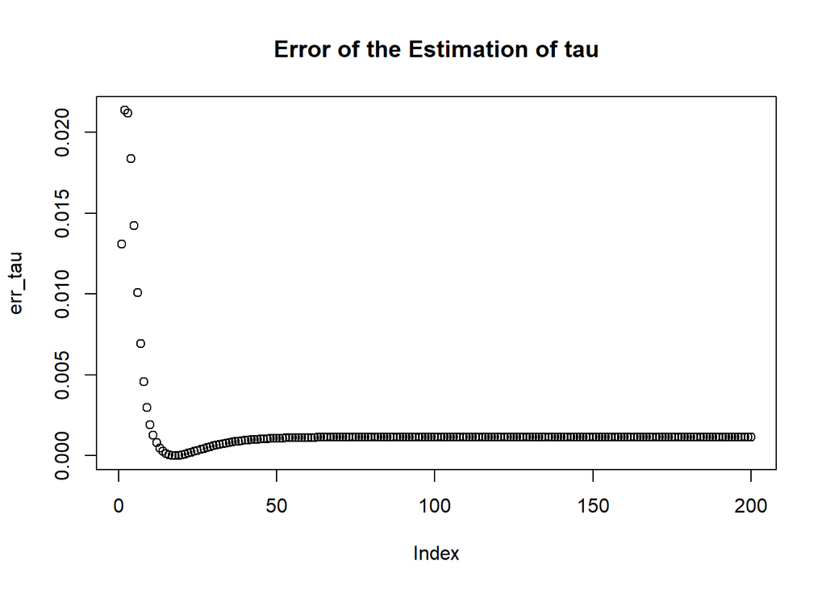

```r
err_tau=rowSums((sweep(out$tau,2,c(0.3,0.7)))^2)
plot(err_tau, main="Error of the Estimation of tau")
```

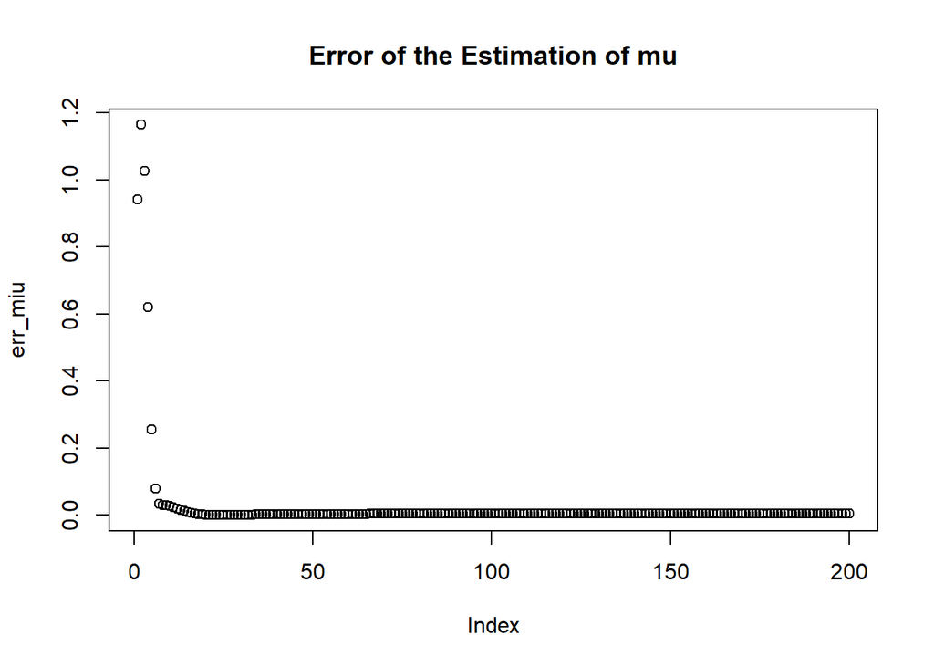

```r
err_miu=rowSums((sweep(out$miu,2,c(0,2)))^2)
plot(err_miu, main="Error of the Estimation of mu")
```

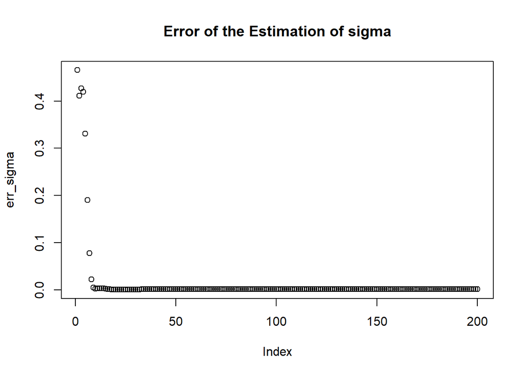

```r
err_sigma=rowSums((sweep(out$sigma,2,c(1,0.5)))^2)
plot(err_sigma, main="Error of the Estimation of sigma")
```

From the picture above, we can see the convergence of the six parameters.

## 2.A (three-category) multinomial mixture problem

### 2.1 EM steps

The multinomial random variable with the following probability mass function

$$f(x|\theta)=\frac{(x_{1}+x_2+x_3)!}{x_{1}!x_2!x_3!}(\frac{4+\theta}{6})^{x_{1}}(\frac{1-\theta}{3})^{x_2}(\frac{\theta}{6})^{x_3}$$

We have

$p_1=\frac{4+\theta}{6}$, $p_2=\frac{1-\theta}{3}$, $p_3=\frac{\theta}{6}$

We know that

$$\sum_{i=1}^3p_i=1$$
we can split $p_1$ into two parts $p_{11}=\frac{2}{3}$, $p_{12}=\frac{\theta}{6}$, so we can get the hidden variable $p_{12}$

$$f(x|\theta)=\frac{(x_{11}+x_{12}+x_2+x_3)!}{x_{11}!x_{12!}!x_2!x_3!}(\frac{2}{3})^{x_{11}}(\frac{\theta}{6})^{x_{12}}(\frac{1-\theta}{3})^{x_2}(\frac{\theta}{6})^{x_3}$$

$$l(\theta|X)=ln(\frac{(x_{11}+x_{12}+x_2+x_3)!}{x_{11}!x_{12!}!x_2!x_3!})+x_{11}ln(\frac{2}{3})+x_{12}ln(\frac{\theta}{6})+x_{2}ln(\frac{1-\theta}{3})+x_{3}ln(\frac{\theta}{6})$$

$$Q(\theta|\theta^{(t+1)})=E_{\theta}[ln(\frac{(x_{11}+x_{12}+x_2+x_3)!}{x_{11}!x_{12!}!x_2!x_3!})+x_{11}ln(\frac{2}{3})+x_{12}ln(\frac{\theta}{6})+x_{2}ln(\frac{1-\theta}{3})+x_{3}ln(\frac{\theta}{6})]$$

The expectation is about $\theta$, so we can have

$$Q(\theta|\theta^{(t+1)})=ln(\frac{(x_{11}+x_{12}+x_2+x_3)!}{x_{11}!x_{12!}!x_2!x_3!})+E_{\theta}(x_{11})ln(\frac{2}{3})+E_{\theta}(x_{12})ln(\frac{\theta}{6})+E_{\theta}(x_{2})ln(\frac{1-\theta}{3})+E_{\theta}(x_{3})ln(\frac{\theta}{6})$$

So when we remove the constant value

$$Q(\theta|\theta^{(t+1)})=E_{\theta}(x_{12}|x_1)ln(\frac{\theta}{6})+x_{2}ln(\frac{1-\theta}{3})+x_{3}ln(\frac{\theta}{6})$$

We know that

$$E_{\theta}(x_{12}|x_1)=\frac{\frac{\theta}{6}}{\frac{4+\theta}{6}}x_1=\frac{\theta}{4+\theta}x_1$$

we can denote it as
$$E_{\theta^{(0)}}(x_{12}|x_1)=\frac{\theta^{(0)}}{4+\theta^{(0)}}x_1=x_{12}^{(0)}$$
So we have Q function that

$$Q(\theta|\theta^{(t+1)})=x_{12}^{(t+1)}ln(\frac{\theta}{6})+x_{2}ln(\frac{1-\theta^{(t+1)}}{3})+x_{3}ln(\frac{\theta^{(t+1)}}{6})$$

Above is the E-step. To maximum Q function above, we can have M-step below

$$[\theta^{(t+1)}]:\frac{6 x_{12}^{(t+1)}}{\theta^{(t+1)}}-\frac{3x_{2}}{1-\theta^{(t+1)}}+\frac{6x_{3}}{\theta^{(t+1)}}=0$$
We finally have

$$\theta^{(t+1)}=\frac{2x_{12}^{(t)}+2x_3}{2x_{12}^{(t)}+x_2+2x_3}$$

$$x_{12}^{(t)}=\frac{\theta^{(t)}}{4+\theta^{(t)}}x_1$$

### 2.2

```r
my_multno_em=function(samp,iteration){
n=length(samp)
threshold <- 1e-5


theta_ini = 0.5
x12_ini=(theta_ini/(4+theta_ini))*samp[1]

out_theta=matrix(rep(0,iteration),nrow=iteration)
out_x12=matrix(rep(0,iteration),nrow=iteration)

out_theta[1,]=theta_ini
out_x12[1,]=x12_ini

for (step in 2:iteration) {

  out_x12[step]=(out_theta[step-1]/(4+out_theta[step-1]))*samp[1]
  out_theta[step]=(2*out_x12[step-1]+2*samp[3])/(2*out_x12[step-1]+2*samp[3]+samp[2])
}
return(mylist=list("theta"=out_theta,"x_12"=out_x12))
}
```

```r
samp=c(42,10,15)
out=my_multno_em(samp,20)
```

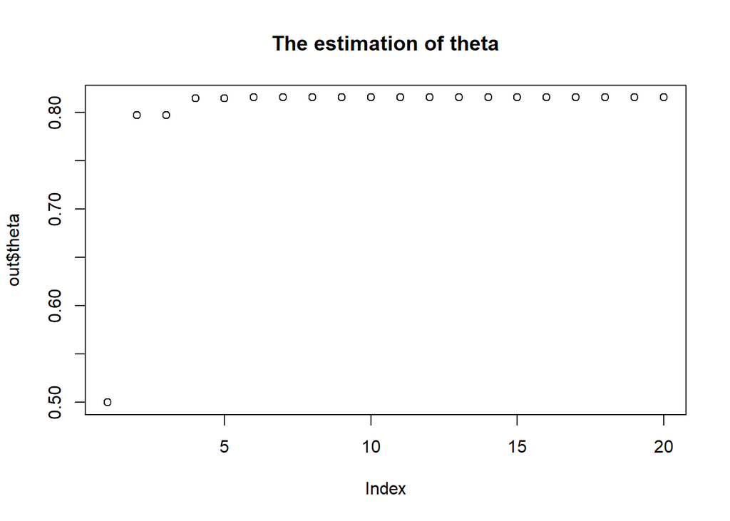

```r
plot(out$theta,main="The estimation of theta")
```

```r
out$theta[20]
```

```
## [1] 0.8155887
```

Above we can find the estimation of $\theta$, It converges to 0.8155887.